# Synapse

2015-05-18

## Slides

Available on [MEP-LINCS project in Synapse (syn4212404)](https://www.synapse.org/#!Synapse:syn4212404/)

## Issues in large data-intensive projects

### People working in parallel across the globe

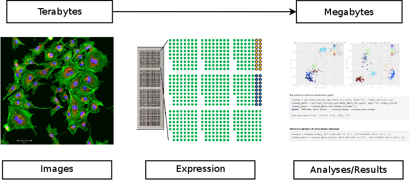

[figure not shown]

- A workspace that allows you to **aggregate**, **describe**, and **share** research
- A tool to improve **reproducibility** of data intensive science, recording progress as you work
- A set of living research projects enabling contribution to large-scale collaborative solutions

[figure not shown]

## Multiple ways to access

### Synapse API

[figure not shown]

## Distributed, versioned file storage

[figure not shown]

http://dx.doi.org/10.7303/syn1773109

## Getting data to Synapse

Use the web interface:

[figure not shown]

or a simple command:

```
synapse store
  --parentId syn3348585 \ # The Analysis folder in MEP-LINCS
  --annotations "{'analysisType': 'stats'}" \ # Some user-defined annotations
  myNewAnalysis.Rmd # The file to upload
```

## Getting data from Synapse

Use the web interface:

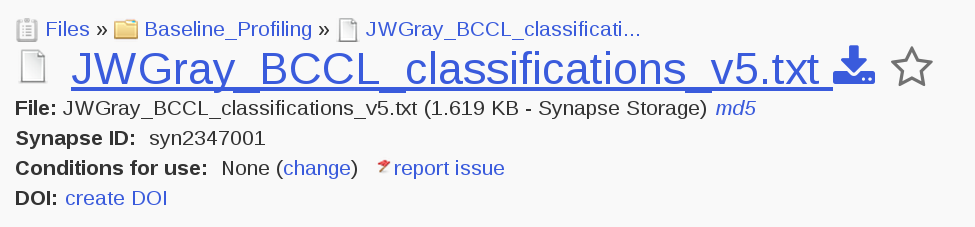

or a simple command:

[output not shown]

## Where the file is stored

### Amazon S3, ExaCloud, Github, FTP, your laptop

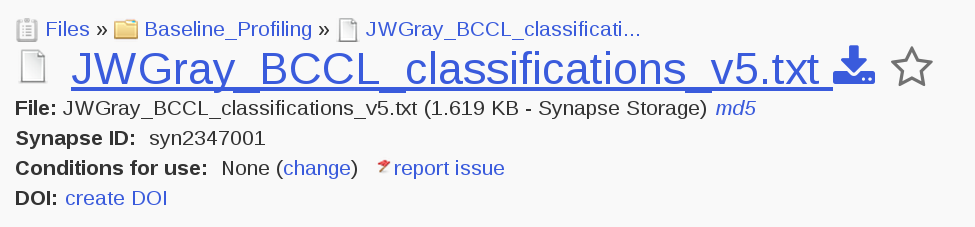

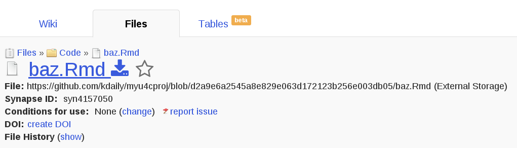

## Annotations & querying

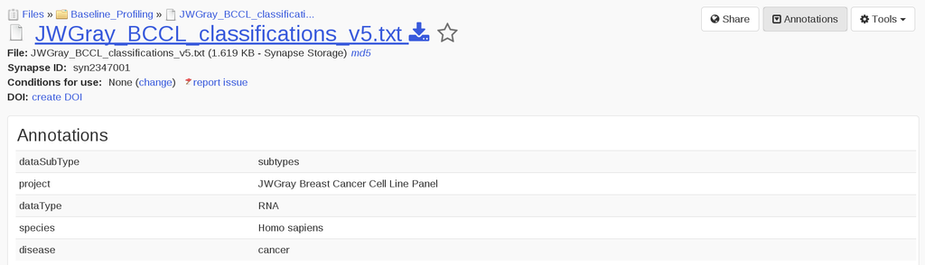

- **Pro**: Completely user-driven
- **Con**: Completely user-driven
- Easily curate and search for specific files

## Annotations & querying

```r
q <- "select * from file where projectId=='syn2346643' and dataSubType=='cna'"
res <- synapseQuery(q)
```

| name | id | dataType | platform | disease |
| --- | --- | --- | --- | --- |
| JWGray_BCCL_SNP6_segmented_pnas.cbs.txt | syn2346649 | DNA | Genome_Wide_SNP_6 | cancer |
| JWGray_BCCL_SNP6_segmented_v2.cbs | syn2347005 | DNA | Genome_Wide_SNP_6 | cancer |
| JWGray_BCCL_SNP6_segmented_v2_gene_level.txt.zip | syn2347007 | DNA | Genome_Wide_SNP_6 | cancer |
| JWGray_BCCL_SNP6_segmented_v2_table_imputed.txt.zip | syn2347008 | DNA | Genome_Wide_SNP_6 | cancer |
| JWGray_BCCL_SNP6_segmented_v2_table.txt.zip | syn2347009 | DNA | Genome_Wide_SNP_6 | cancer |

[JWGray Breast Cancer Cell Line Panel (syn2346643)](https://www.synapse.org/#!Synapse:syn2346643/)

## Structured data tables

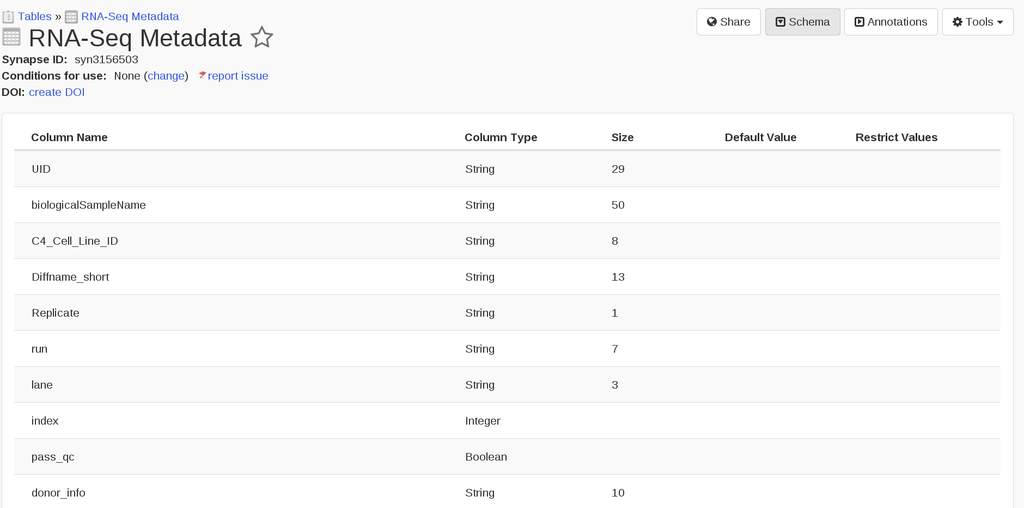

[syn3156503](https://www.synapse.org/#!Synapse:syn3156503/)

## Structured data tables

```
SELECT UID,biologicalSampleName,Diffname_short,pass_qc,Cell_Type,Cell_Line_Type,Tissue_of_Origin
FROM syn3156503 WHERE public=true
```

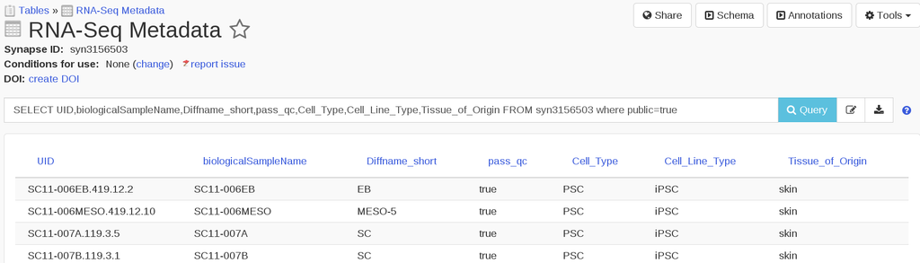

See the query

## Structured data tables

- Rows are versioned
- Create/Update/Delete
- Editable in the browser or programmatically
- Use cases:
  - Tabular data files
  - Storing controlled vocabulary metadata
  - Curated file listings

## Documentation and description

[figure not shown]

## Documentation and description

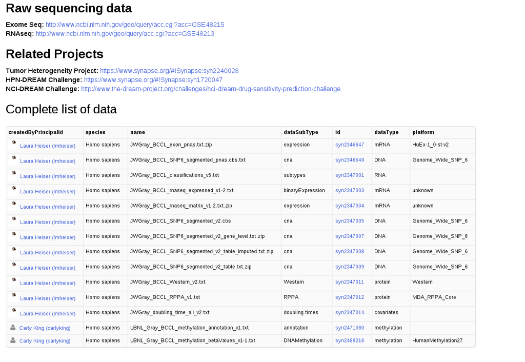

## Wikis from RMarkdown and IPython

### Sage-Bionetworks/knit2synapse

[figure not shown]

[syn2233188](https://www.synapse.org/#!Synapse:syn2233188/)

## Where a file comes from (provenance)

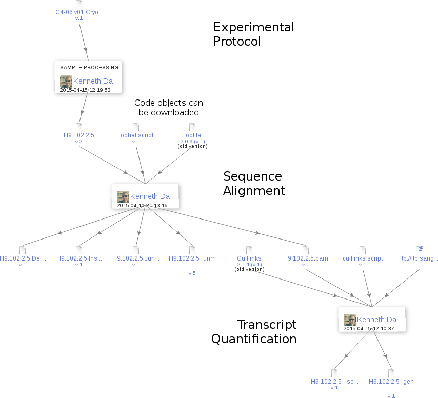

## Security and Access Restrictions

- Users and groups
- Fine-grained access controls at multiple levels
  - File
  - Folder
  - Project

## Synapse

### Security and Access Restrictions

[figure not shown]

## Automation

### Uploading, Updating, etc.

- New files in ExaCloud \(\rightarrow\) Synapse
- Annotation of files
- Provenance
- Available file listings
- Analysis code

## Building external tools

### LI4V002C2 Spot MEMA Dataset Explorer (Mark Dane)

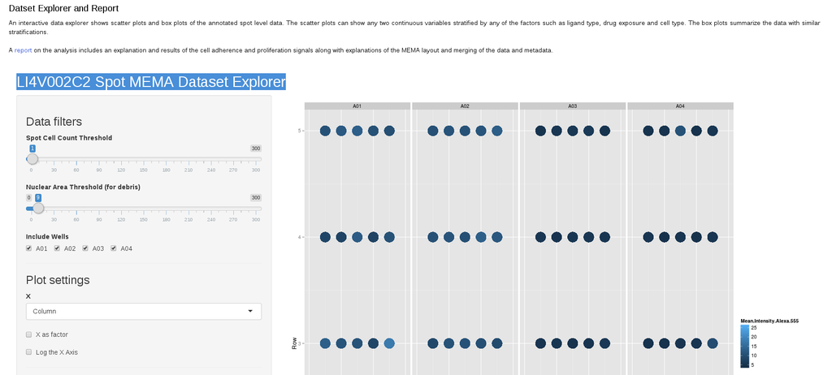

https://www.synapse.org/#!Synapse:syn3157640/wiki/

## Building external tools

### PCBC Heatmap Explorer

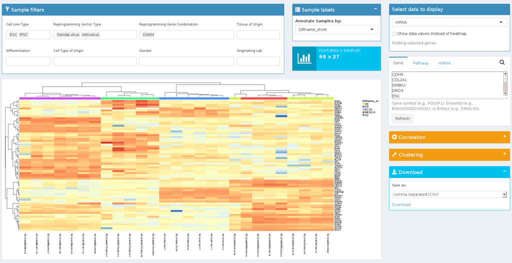

## Example projects

### To draw inspiration

- [AMP AD Knowledge Portal](https://www.synapse.org/#!Synapse:syn2580853)
- [Progenitor Cell Biology Consortium](https://www.synapse.org/#!Synapse:syn1773109)
- [JWGray Breast Cancer Cell Line Panel](https://www.synapse.org/#!Synapse:syn2346643)
- [NCI Up For A Challenge](https://www.synapse.org/#!Synapse:syn3157598)

For more, see [Research Communities](https://www.synapse.org/#!Synapse:syn3722562/wiki/219258) and [Open Resources](https://www.synapse.org/#!Synapse:syn3722562/wiki/219259).

## Extensive documentation and examples

- [Synapse Tutorial](https://www.synapse.org/#!Help:GettingStarted)
- [Support Forums](http://support.sagebase.org/sagebase)
- [Interactive Guide (Mad Scientist Stu)](https://www.synapse.org/#!Help:Collaboratorium)
- [R](http://r-docs.synapse.org/) [client](https://www.synapse.org/#!Help:RClient)
- [Python](http://python-docs.synapse.org/) [client](https://www.synapse.org/#!Help:PythonClient)
- [Command line](http://python-docs.synapse.org/CommandLineClient.html) [client](https://www.synapse.org/#!Help:CommandLineClient)
- [github:Sage-Bionetworks/synapseTutorials](https://github.com/Sage-Bionetworks/synapseTutorials)
- kenneth.daily@sagebase.org

## Thank you!

### Questions?

- [MEP-LINCS](http://www.lincsproject.org/centers/data-and-signature-generating-centers/oregon-u/) Group
- [Sage Bionetworks](http://sagebase.org/)